```python
# suggested libraries
def configure_plotly_browser_state():
  import IPython
  display(IPython.core.display.HTML('''
        <script src="/static/components/requirejs/require.js"></script>
        <script>
          requirejs.config({
            paths: {
              base: '/static/base',
              plotly: 'https://cdn.plot.ly/plotly-1.5.1.min.js?noext',
            },
          });
        </script>
        '''))
import chart_studio.plotly as py
import numpy as np
from plotly.offline import init_notebook_mode, iplot
from plotly.graph_objs import Contours, Histogram2dContour, Marker, Scatter
import plotly.graph_objs as go

configure_plotly_browser_state()
init_notebook_mode(connected=False)
import pandas as pd
import plotly.express as px
import matplotlib.pyplot as plt
```

# The Team

### Kevin Farragher

#### Role:

Answered the following questions that our group sought to get answers to, using exploratory data analysis and visualization (if applicable):

- Which 5 years had the highest and lowest median age for males getting married between 1991 and 2015?
- Which 5 years had the highest and lowest median age for females getting married between 1991 and 2015?
- From 1991 to 2015, how many years was the median age for men getting married greater than the median age for women getting married?
- How did the median age for males and females getting married change from 1991 to 2015?
- From 1991 to 2015, how many years was the number of men marrying per 1,000 unmarried men greater than the number of women marrying per 1,000 unmarried women?
- How did the number of men and marrying per 1,000 unmarried men and number of women marrying per 1,000 unmarried women change from 1991 to 2015?
- From 1991 to 2015, how many years was the number of men marrying for the first time per 1,000 people greater than number of women marrying for the first time per 1,000 people?
- How did the number of men marrying for the first time per 1,000 people and number of women marrying for the first time per 1,000 people change from 1991 to 2015?
- From 1991 to 2015, how many years was the number of men remarrying per 1,000 people greater than the number of women remarrying per 1,000 people?
- How did the number of men remarrying per 1,000 people and number of women remarrying per 1,000 people change from 1991 to 2015?
- From 1991 to 2015, how many years was the number of men marrying for the first time per 1,000 people greater than the number of men remarrying per 1,000 people?
- From 1991 to 2015, how many years was the number of women marrying for the first time per 1,000 people greater than the number of women remarrying per 1,000 people?

Also, I was the perosn who combined our notebooks together and put together our final notebook with the required sections.

### Mark Beebe

#### Role:

# Analyzing UK Marriage and Divorce Data

# Problem Statement and Background

A high-level statement of the problem you intend to address, e.g. finding correspondences between geo locations and crime rates. Translate the high-level description into specific questions. Give background on the problem you are solving: why it is interesting, who is interested, what is known, some references about it, etc.

The problem we intend to address is trying to find interesting statistics and relationships between the attributes from our dataset, which contains data on UK divorce and marriage, and visualizing them with graphs. The problem we intend to address is important because by finding interesting statistics and relationships between the attributes from our dataset, which contains data on UK marriage and divorce, we can gather insights on UK marriage and divorce and find out about information relating to UK marriage and divorce that may not be obvious or known to people.

# The Data Source

Describe the data source(s) you used. Describe how you accessed the data. Give a summary of the cleaning/joining of data that you had to do up front. Provide links and references to your data source.

Our dataset contains information about divorce and marriage in the United Kingdom from 1901 to 2016. The dataset was retrieved from Kaggle (https://www.kaggle.com/osbornep/uk-marriage-and-divorce-figures). The data in the dataset related to UK marriage was gathered from https://www.ons.gov.uk/peoplepopulationandcommunity/birthsdeathsandmarriages/marriagecohabitationandcivilpartnerships/datasets/marriagesinenglandandwales2013, and the data in the dataset related to UK divorce was gathered from https://www.ons.gov.uk/peoplepopulationandcommunity/birthsdeathsandmarriages/divorce/datasets/divorcesinenglandandwales. Specifically, the dataset contains annual information (relating to divorce and marriage in the UK from 1901 to 2016) on the:

- number of divorces
- number of husbands who submitted for divorce
- number of wives who submitted for divorce
- divorce rate for males of various age groups
- divorce rate for females of various age groups
- number of husbands who submitted for divorce because of adultery and unreasonable behavior
- number of wives who submitted for divorce because of adultery and unreasonable behavior
- number of marriages
- number of marriages that consisted of people who both married for the first time
- number of marriages that consisted of a person who previously divorced
- number of marriages that consisted of people who both previously divorced
- number of marriages that consisted of the husband previously divorcing
- number of marriages that consisted of the wife previously divorcing
- median age of males getting married
- median age of females getting married
- number of people marrying per 1,000 people
- number of men marrying per 1,000 unmarried men
- number of women marrying per 1,000 unmarried women
- number of men marrying for the first time per 1,000 people
- number of women marrying for the first time per 1,000 people
- number of men remarrying per 1,000 people
- number of women remarrying per 1,000 people

```python
#loading in and showing head of thedataset
uk_divorce_marriage_df = pd.read_csv("UKDivorceAndMarriage.csv")
uk_divorce_marriage_df.head()
```

|  | Year | Total Number of Divorces | Husband Submitted Divorce | Wife Submitted Divorce | DRMale 20 to 24 | DRMale 25 to 29 | DRMale 30 to 34 | DRMale 35 to 39 | DRMale 40 to 44 | DRMale 45 to 49 | ... | Wife - Previously Divorced | Median Age of Single Males Marriage | Median Age of Single Females Marriage | Persons marrying per 1,000 population of all ages | Men marrying per 1,000 unmarried1 men aged 16 and over | Women marrying per 1,000 unmarried1 women aged 16 and over | Number Men First Time marrying per 1,000 single population aged 16 and over | Number Women First Time marrying per 1,000 single population aged 16 and over | Number Men Re-marrying per 1,000 single population aged 16 and over | Number Women Re-marrying per 1,000 single population aged 16 and over |
| --- | --- | --- | --- | --- | --- | --- | --- | --- | --- | --- | --- | --- | --- | --- | --- | --- | --- | --- | --- | --- | --- |
| 0 | 2016 | 106,959 | 41,669 | 65,290 | 9.4 | 13.2 | 13.0 | 13.4 | 13.6 | 13.8 | ... | 18,670 | NaN | NaN | NaN | NaN | NaN | NaN | NaN | NaN | NaN |
| 1 | 2015 | 101,055 | 38,490 | 62,565 | 10.5 | 13.0 | 11.9 | 12.6 | 13.1 | 12.6 | ... | 17,231 | 31.5 | 29.7 | 8.3 | 21.7 | 19.8 | 20.7 | 24.3 | 25.4 | 12.5 |
| 2 | 2014 | 111,169 | 41,364 | 69,803 | 13.2 | 13.5 | 14.0 | 13.9 | 14.6 | 13.7 | ... | 19,726 | 31.2 | 29.5 | 8.6 | 23.0 | 20.9 | 22.1 | 25.9 | 26.2 | 12.8 |
| 3 | 2013 | 114,720 | 40,635 | 74,076 | 14.7 | 15.9 | 15.8 | 16.7 | 16.7 | 15.3 | ... | 21,257 | 31.1 | 29.3 | 8.5 | 22.5 | 20.4 | 21.7 | 25.6 | 25.3 | 12.2 |
| 4 | 2012 | 118,140 | 41,601 | 76,490 | 17.5 | 17.4 | 17.3 | 17.9 | 17.8 | 15.8 | ... | 22,222 | 31.0 | 29.1 | 9.3 | 24.6 | 22.5 | 23.9 | 28.4 | 27.2 | 13.4 |

5 rows × 39 columns

### Dataset Cleaning

When the dataset was initially inspected, we found that the dataset had many years (entries/rows) with null values, and the data types of some of the columns/attributes in the dataset were improper. As a result, we decided to clean up the original dataset by removing the years with null values and changing the data types of columns with improper data types to proper ones. From these changes, we will be analyzing divorce and marriage data in the UK from 1991 to 2015, which we feel is still a large enough chunk of the dataset to gather valuable insights from.

### Dataset processing and cleaning

```python
#removing years (entries/rows) with null/empty values from the dataset
uk_divorce_marriage_df=uk_divorce_marriage_df.iloc[1:26,:]
uk_divorce_marriage_df
```

|  | Year | Total Number of Divorces | Husband Submitted Divorce | Wife Submitted Divorce | DRMale 20 to 24 | DRMale 25 to 29 | DRMale 30 to 34 | DRMale 35 to 39 | DRMale 40 to 44 | DRMale 45 to 49 | ... | Wife - Previously Divorced | Median Age of Single Males Marriage | Median Age of Single Females Marriage | Persons marrying per 1,000 population of all ages | Men marrying per 1,000 unmarried1 men aged 16 and over | Women marrying per 1,000 unmarried1 women aged 16 and over | Number Men First Time marrying per 1,000 single population aged 16 and over | Number Women First Time marrying per 1,000 single population aged 16 and over | Number Men Re-marrying per 1,000 single population aged 16 and over | Number Women Re-marrying per 1,000 single population aged 16 and over |
| --- | --- | --- | --- | --- | --- | --- | --- | --- | --- | --- | --- | --- | --- | --- | --- | --- | --- | --- | --- | --- | --- |
| 1 | 2015 | 101,055 | 38,490 | 62,565 | 10.5 | 13.0 | 11.9 | 12.6 | 13.1 | 12.6 | ... | 17,231 | 31.5 | 29.7 | 8.3 | 21.7 | 19.8 | 20.7 | 24.3 | 25.4 | 12.5 |
| 2 | 2014 | 111,169 | 41,364 | 69,803 | 13.2 | 13.5 | 14.0 | 13.9 | 14.6 | 13.7 | ... | 19,726 | 31.2 | 29.5 | 8.6 | 23.0 | 20.9 | 22.1 | 25.9 | 26.2 | 12.8 |
| 3 | 2013 | 114,720 | 40,635 | 74,076 | 14.7 | 15.9 | 15.8 | 16.7 | 16.7 | 15.3 | ... | 21,257 | 31.1 | 29.3 | 8.5 | 22.5 | 20.4 | 21.7 | 25.6 | 25.3 | 12.2 |
| 4 | 2012 | 118,140 | 41,601 | 76,490 | 17.5 | 17.4 | 17.3 | 17.9 | 17.8 | 15.8 | ... | 22,222 | 31.0 | 29.1 | 9.3 | 24.6 | 22.5 | 23.9 | 28.4 | 27.2 | 13.4 |
| 5 | 2011 | 117,558 | 40,414 | 77,083 | 19.5 | 17.1 | 18.8 | 17.9 | 18.0 | 15.4 | ... | 22,716 | 30.9 | 29.1 | 8.9 | 23.4 | 21.3 | 22.6 | 26.6 | 26.2 | 12.9 |
| 6 | 2010 | 119,589 | 40,338 | 79,178 | 15.5 | 17.8 | 17.7 | 19.3 | 17.9 | 15.4 | ... | 23,240 | 30.8 | 29.0 | 8.8 | 23.6 | 21.3 | 22.7 | 27.0 | 26.8 | 12.6 |
| 7 | 2009 | 113,949 | 38,043 | 75,834 | 14.2 | 18.2 | 17.4 | 17.6 | 16.4 | 14.9 | ... | 22,394 | 30.8 | 28.9 | 8.4 | 22.8 | 20.5 | 21.7 | 25.9 | 26.7 | 12.6 |
| 8 | 2008 | 121,708 | 40,143 | 81,466 | 14.0 | 17.7 | 18.5 | 19.1 | 17.8 | 15.7 | ... | 24,049 | 30.8 | 28.8 | 8.6 | 23.5 | 21.0 | 21.9 | 26.1 | 28.9 | 13.6 |
| 9 | 2007 | 128,131 | 40,878 | 87,151 | 16.6 | 19.5 | 20.1 | 20.1 | 18.8 | 15.9 | ... | 25,433 | 30.8 | 28.7 | 8.7 | 24.0 | 21.4 | 22.1 | 26.4 | 30.6 | 14.1 |
| 10 | 2006 | 132,140 | 41,638 | 90,375 | 20.0 | 21.0 | 20.8 | 20.7 | 19.5 | 16.4 | ... | 26,638 | 30.8 | 28.6 | 8.9 | 24.9 | 22.0 | 22.7 | 27.1 | 32.8 | 14.8 |
| 11 | 2005 | 141,322 | 44,537 | 96,644 | 23.3 | 23.7 | 22.9 | 22.2 | 20.7 | 16.9 | ... | 28,609 | 30.7 | 28.5 | 9.3 | 26.4 | 23.3 | 23.9 | 28.5 | 34.5 | 16.0 |
| 12 | 2004 | 152,923 | 47,580 | 105,177 | 21.8 | 26.2 | 26.2 | 25.2 | 22.5 | 17.7 | ... | 30,385 | 30.4 | 28.3 | 10.3 | 29.4 | 26.0 | 26.9 | 32.4 | 37.8 | 17.6 |
| 13 | 2003 | 153,065 | 46,883 | 106,013 | 30.5 | 26.5 | 27.7 | 25.5 | 22.2 | 16.8 | ... | 30,307 | 30.3 | 28.1 | 10.2 | 29.8 | 26.2 | 27.1 | 32.8 | 38.9 | 17.6 |
| 14 | 2002 | 147,735 | 44,771 | 102,796 | 19.8 | 27.5 | 27.5 | 24.1 | 20.6 | 16.1 | ... | 29,056 | 30.5 | 27.9 | 9.7 | 28.8 | 25.1 | 26.3 | 31.7 | 36.9 | 16.7 |
| 15 | 2001 | 143,818 | 44,480 | 99,140 | 21.6 | 27.9 | 28.3 | 25.0 | 20.5 | 15.3 | ... | 28,056 | 29.7 | 27.7 | 9.5 | 27.4 | 23.7 | 25.5 | 30.6 | 33.2 | 15.2 |
| 16 | 2000 | 141,135 | 42,452 | 98,438 | 23.9 | 27.9 | 27.4 | 24.1 | 19.5 | 15.0 | ... | 27,433 | 29.6 | 27.5 | 10.3 | 30.1 | 25.9 | 27.7 | 33.2 | 37.4 | 17.1 |
| 17 | 1999 | 144,556 | 43,539 | 100,664 | 25.9 | 29.7 | 28.4 | 24.2 | 19.5 | 14.5 | ... | 27,917 | 29.2 | 27.3 | 10.1 | 30.1 | 25.8 | 28.0 | 33.5 | 36.6 | 16.7 |
| 18 | 1998 | 145,214 | 43,053 | 101,795 | 27.4 | 30.7 | 28.4 | 24.0 | 18.9 | 14.4 | ... | 27,231 | 28.9 | 27.0 | 10.3 | 31.1 | 26.6 | 28.9 | 34.7 | 37.9 | 17.2 |
| 19 | 1997 | 146,689 | 43,889 | 102,373 | 27.5 | 30.4 | 28.7 | 23.6 | 18.6 | 14.0 | ... | 27,066 | 28.6 | 26.7 | 10.6 | 32.3 | 27.5 | 29.7 | 35.6 | 39.9 | 18.1 |
| 20 | 1996 | 157,107 | 46,884 | 109,732 | 29.4 | 32.6 | 30.2 | 24.8 | 19.4 | 14.5 | ... | 28,767 | 28.3 | 26.4 | 10.9 | 33.6 | 28.5 | 31.1 | 37.3 | 41.2 | 18.7 |
| 21 | 1995 | 155,499 | 45,985 | 109,023 | 29.0 | 31.5 | 29.6 | 24.1 | 19.0 | 14.2 | ... | 28,006 | 27.9 | 26.0 | 11.0 | 34.7 | 29.4 | 32.4 | 39.3 | 41.4 | 18.4 |
| 22 | 1994 | 158,175 | 45,112 | 112,640 | 29.0 | 31.5 | 29.9 | 24.3 | 19.1 | 14.2 | ... | 27,865 | 27.5 | 25.7 | 11.4 | 36.3 | 30.6 | 34.3 | 41.6 | 42.3 | 18.6 |
| 23 | 1993 | 165,018 | 46,271 | 118,401 | 29.2 | 33.0 | 30.8 | 25.1 | 19.7 | 14.4 | ... | 28,638 | 27.2 | 25.3 | 11.7 | 37.7 | 31.8 | 35.8 | 43.8 | 43.4 | 18.7 |
| 24 | 1992 | 160,385 | 44,378 | 115,628 | 26.6 | 32.1 | 29.5 | 23.6 | 18.7 | 14.0 | ... | 27,189 | 26.8 | 25.0 | 12.2 | 39.6 | 33.4 | 37.8 | 46.3 | 45.1 | 19.3 |
| 25 | 1991 | 158,745 | 44,160 | 114,192 | 26.7 | 32.4 | 28.6 | 23.1 | 17.7 | 13.6 | ... | 26,226 | 26.5 | 24.6 | 12.1 | 39.3 | 33.2 | 37.8 | 46.7 | 43.8 | 18.6 |

25 rows × 39 columns

```python
#converting the data type of columns with object data types to int
uk_divorce_marriage_df['Total Number of Divorces'] = uk_divorce_marriage_df['Total Number of Divorces'].astype(str)
uk_divorce_marriage_df['Total Number of Divorces'] = uk_divorce_marriage_df['Total Number of Divorces'].str.replace(',', '').astype(int)
uk_divorce_marriage_df['Husband Submitted Divorce'] = uk_divorce_marriage_df['Husband Submitted Divorce'].astype(str)
uk_divorce_marriage_df['Husband Submitted Divorce'] = uk_divorce_marriage_df['Husband Submitted Divorce'].str.replace(',', '').astype(int)
uk_divorce_marriage_df['Wife Submitted Divorce'] = uk_divorce_marriage_df['Wife Submitted Divorce'].astype(str)
uk_divorce_marriage_df['Wife Submitted Divorce'] = uk_divorce_marriage_df['Wife Submitted Divorce'].str.replace(',', '').astype(int)
uk_divorce_marriage_df['Total Number of Marriages'] = uk_divorce_marriage_df['Total Number of Marriages'].astype(str)
uk_divorce_marriage_df['Total Number of Marriages'] = uk_divorce_marriage_df['Total Number of Marriages'].str.replace(',', '').astype(int)
uk_divorce_marriage_df['First marriage of both parties'] = uk_divorce_marriage_df['First marriage of both parties'].astype(str)
uk_divorce_marriage_df['First marriage of both parties'] = uk_divorce_marriage_df['First marriage of both parties'].str.replace(',', '').astype(int)
uk_divorce_marriage_df['One party previously divorced'] = uk_divorce_marriage_df['One party previously divorced'].astype(str)
uk_divorce_marriage_df['One party previously divorced'] = uk_divorce_marriage_df['One party previously divorced'].str.replace(',', '').astype(int)
uk_divorce_marriage_df['Both parties previously divorced'] = uk_divorce_marriage_df['Both parties previously divorced'].astype(str)
uk_divorce_marriage_df['Both parties previously divorced'] = uk_divorce_marriage_df['Both parties previously divorced'].str.replace(',', '').astype(int)
uk_divorce_marriage_df['Husband - Previously Divorced'] = uk_divorce_marriage_df['Husband - Previously Divorced'].astype(str)
uk_divorce_marriage_df['Husband - Previously Divorced'] = uk_divorce_marriage_df['Husband - Previously Divorced'].str.replace(',', '').astype(int)
uk_divorce_marriage_df['Wife - Previously Divorced'] = uk_divorce_marriage_df['Wife - Previously Divorced'].astype(str)
uk_divorce_marriage_df['Wife - Previously Divorced'] = uk_divorce_marriage_df['Wife - Previously Divorced'].str.replace(',', '').astype(int)
#converting the data type of the "Year" column to object
uk_divorce_marriage_df['Year'] = uk_divorce_marriage_df['Year'].astype(object)
```

# Goal of our Analysis

List the goal of your analysis, ideally in the form of testable hypothesis, or via well-defined success metrics. You initial hypotheses may have changed throughout your project, but you should always approach the data with some expectations so that your efforts are focused.

The goal of our analysis is to find answers to the following questions:

- Which 5 years had the highest and lowest number of marriages between 1991 and 2015?
- Which 5 years had the highest and lowest number of divorces between 1991 and 2015?
- How did the number of divorces and marriages change from 1991 to 2015?
- From 1991 to 2015, how many years did husbands file for divorce more than wives?
- How did the number of divorces filed by husbands and wives change from 1991 to 2015?
- Between 1991 and 2015, which age group between ages 20-59 had the highest/lowest average divorce rate for males?
- Between 1991 and 2015, which age group between ages 20-59 had the highest/lowest average divorce rate for females?
- How did the divorce rate for males aged 20-24, males aged 25-29, males aged 30-34, males aged 35-39, males aged 40-44, males aged 45-49, males aged 50-54, and males aged 55-59 change from 1991 to 2015?
- How did the divorce rate for females aged 20-24, females aged 25-29, females aged 30-34, females aged 35-39, females aged 40-44, females aged 45-49, females aged 50-54, and females aged 55-59 change from 1991 to 2015?
- Between 1991 and 2015, was the divorce rates for different age ranges significantly different? Has the divorce rate for different ranges changed since 1991? Which age groups were most likely to divorce?
- Between 1991 and 2015, which age group had the highest divorce rate per year?
- Between 1991 and 2015, were husbands more likely to divorce because of adultery, or because of unreasonable behavior?
- Between 1991 and 2015, were wives more likely to divorce because of adultery, or because of unreasonable behavior?
- Between 1991 and 1995, how did the causes of divorce (filing for divorce because of adultery and filing for divorce because of unreasonable behavior) change over time?
- Between 1991 and 2015, how many marriages consisted of people who both married for the first time, a person who previously divorced, people who both previously divorced, the husband previously divorcing, and the wife previously divorcing?
- How did the number of marriages consisting of people who both married for the first time, a person who previously divorced, people who both previously divorced, the husband previously divorcing, and the wife previously divorcing change from 1991 to 2015?
- Which 5 years had the highest and lowest median age for males getting married between 1991 and 2015?
- Which 5 years had the highest and lowest median age for females getting married between 1991 and 2015?
- From 1991 to 2015, how many years was the median age for men getting married greater than the median age for women getting married?
- How did the median age for males and females getting married change from 1991 to 2015?
- From 1991 to 2015, how many years was the number of men marrying per 1,000 unmarried men greater than the number of women marrying per 1,000 unmarried women?
- How did the number of men and marrying per 1,000 unmarried men and number of women marrying per 1,000 unmarried women change from 1991 to 2015?
- From 1991 to 2015, how many years was the number of men marrying for the first time per 1,000 people greater than number of women marrying for the first time per 1,000 people?
- How did the number of men marrying for the first time per 1,000 people and number of women marrying for the first time per 1,000 people change from 1991 to 2015?
- From 1991 to 2015, how many years was the number of men remarrying per 1,000 people greater than the number of women remarrying per 1,000 people?
- How did the number of men remarrying per 1,000 people and number of women remarrying per 1,000 people change from 1991 to 2015?
- From 1991 to 2015, how many years was the number of men marrying for the first time per 1,000 people greater than the number of men remarrying per 1,000 people?
- From 1991 to 2015, how many years was the number of women marrying for the first time per 1,000 people greater than the number of women remarrying per 1,000 people?

# Data Analysis

Describe the tools you used throughout the project. Most likely, you project included several stages in the project such as exploratory data analysis, modeling (using machine learning), and possibly a scale-up from a sample of data to the full dataset. Describe all stages of your project.

The tools we used throughout the project to find the answers to our questions relating to UK divorce and marriage include exploratory data analysis and visualization. Exploratory data analysis was used to perform data wrangling and to find the answers to our questions relating to UK divorce and marriage. Visualization was used to to visualize the answers to our questions relating to UK divorce and marriage (if applicable) by using a variety of graphs and plots, such as bar graphs and line graphs. Initially, our project focused on exploratory data analysis to find the answers to our questions relating to UK divorce and marriage. Once the answers to our questions were found, our project focused on visualizing the answers to our questions (if applicable) by using a variety of graphs.

# Results/Findings

```python
#dataset's columns
uk_divorce_marriage_df.columns
```

```
Index(['Year', 'Total Number of Divorces', 'Husband Submitted Divorce',
       'Wife Submitted Divorce', 'DRMale 20 to 24', 'DRMale 25 to 29',
       'DRMale 30 to 34', 'DRMale 35 to 39', 'DRMale 40 to 44',
       'DRMale 45 to 49', 'DRMale 50 to 54', 'DRMale 55 to 59',
       'DRFemale 20 to 24', 'DRFemale 25 to 29', 'DRFemale 30 to 34',
       'DRFemale 35 to 39', 'DRFemale 40 to 44', 'DRFemale 45 to 49',
       'DRFemale 50 to 54', 'DRFemale 55 to 59',
       'Husband Submitted - Reason Adultery',
       'Husband Submitted - Reason Unreasonable Behaviour',
       'Wife Submitted - Reason Adultery',
       'Wife Submitted - Reason Unreasonable Behaviour',
       'Total Number of Marriages', 'First marriage of both parties',
       'One party previously divorced', 'Both parties previously divorced',
       'Husband - Previously Divorced', 'Wife - Previously Divorced',
       'Median Age of Single Males Marriage',
       'Median Age of Single Females Marriage',
       'Persons marrying per 1,000 population of all ages',
       'Men marrying per 1,000 unmarried1 men aged 16 and over',
       'Women marrying per 1,000 unmarried1 women aged 16 and over',
       'Number Men First Time marrying per 1,000 single population aged 16 and over',
       'Number Women First Time marrying per 1,000 single population aged 16 and over',
       'Number Men Re-marrying per 1,000 single population aged 16 and over',
       'Number Women Re-marrying per 1,000 single population aged 16 and over'],
      dtype='object')
```

### Which 5 years had the highest and lowest number of marriages between 1991 and 2015?

The tables below show the 5 years with the highest and lowest number of marriages between 1991 and 2015. Between 1991 and 2015, the 5 years with the highest number of marriages were 1992, 1991, 1993, 1994, and 1995. The 5 years with the lowest number of marriages were 2009, 2007, 2008, 2015, and 2006. Over time, marriage became less frequent.

```python
top5_years_marriages=uk_divorce_marriage_df[['Year','Total Number of Marriages']].sort_values('Total Number of Marriages', ascending=False).head(5)
top5_years_marriages
```

|  | Year | Total Number of Marriages |
| --- | --- | --- |
| 24 | 1992 | 311564 |
| 25 | 1991 | 306756 |
| 23 | 1993 | 299197 |
| 22 | 1994 | 291069 |
| 21 | 1995 | 283012 |

```python
bottom5_years_marriages=uk_divorce_marriage_df[['Year','Total Number of Marriages']].sort_values('Total Number of Marriages', ascending=True).head(5)
bottom5_years_marriages
```

|  | Year | Total Number of Marriages |
| --- | --- | --- |
| 7 | 2009 | 232443 |
| 9 | 2007 | 235367 |
| 8 | 2008 | 235794 |
| 1 | 2015 | 239020 |
| 10 | 2006 | 239454 |

### Which 5 years had the highest and lowest number of divorces between 1991 and 2015?

The tables below show the 5 years with the highest and lowest number of divorces between 1991 and 2015. Between 1991 and 2015, the 5 years with the highest number of divorces were 1993, 1992, 1991, 1994, and 1996. The 5 years with the lowest number of divorces were 2015, 2014, 2009, 2013, and 2011. Over time, divorces became less frequent.

```python
top5_years_divorces=uk_divorce_marriage_df[['Year','Total Number of Divorces']].sort_values('Total Number of Divorces', ascending=False).head(5)
top5_years_divorces
```

|  | Year | Total Number of Divorces |
| --- | --- | --- |
| 23 | 1993 | 165018 |
| 24 | 1992 | 160385 |
| 25 | 1991 | 158745 |
| 22 | 1994 | 158175 |
| 20 | 1996 | 157107 |

```python
bottom5_years_divorces=uk_divorce_marriage_df[['Year','Total Number of Divorces']].sort_values('Total Number of Divorces', ascending=True).head(5)
bottom5_years_divorces
```

|  | Year | Total Number of Divorces |
| --- | --- | --- |
| 1 | 2015 | 101055 |
| 2 | 2014 | 111169 |
| 7 | 2009 | 113949 |
| 3 | 2013 | 114720 |
| 5 | 2011 | 117558 |

### How did the number of divorces and marriages change from 1991 to 2015?

The line graph below visualizes how the number of divorces and marriages changed from 1991 and to 2015. From 1991 to 2015, the number of marriages and divorces decreased. Marriage and divorce became less common over the years.

```python
uk_divorce_marriage_df_long=pd.melt(uk_divorce_marriage_df, id_vars=['Year'], value_vars=['Total Number of Divorces', 'Total Number of Marriages'])
fig = px.line(uk_divorce_marriage_df_long, x='Year', y='value', color='variable')
fig.show()
```

[interactive chart not shown]

### From 1991 to 2015, how many years did husbands file for divorce more than wives?

The code below was used to determine the number of years husbands filed for divorce more than wives from 1991 to 2015. From 1991 to 2015, the number of years husbands filed for divorce more than wives was 0. Every year, husbands filed for divorce less than wives, showing that wives were more likely to file for divorce than husbands.

```python
years=0
for i in range(1,uk_divorce_marriage_df.shape[0]+1):
    num_husbands_filed_divorce=uk_divorce_marriage_df.loc[i,'Husband Submitted Divorce']
    num_wives_filed_divorce=uk_divorce_marriage_df.loc[i,'Wife Submitted Divorce']
    if(num_husbands_filed_divorce>num_wives_filed_divorce):
        years=years+1
print("The number of years husbands filed for divorce more than women:",years)
```

```
The number of years husbands filed for divorce more than women: 0
```

### How did the number of divorces filed by husbands and wives change from 1991 to 2015?

The line graph below visualizes how the number of divorces being filed by husbands and wives changed from 1991 and to 2015. From 1991 to 2015, the number divorces filed by wives decreased, while the number of divorces filed by husbands remained constant. Wives filed for divorce less often over the years, and men filed for divorce at the same rate over the years. Overall, wives submitted for divorce at a significantly higher rate than husbands. However, over the years, the gap between the number of wives filing for divorce and the number of husbands filing for divorce decreased from about three times as much to two times as much.

```python
uk_filed_divorce_df_long=pd.melt(uk_divorce_marriage_df, id_vars=['Year'], value_vars=['Husband Submitted Divorce', 'Wife Submitted Divorce'])
fig = px.line(uk_filed_divorce_df_long, x='Year', y='value', color='variable')
fig.show()
```

[interactive chart not shown]

### Between 1991 and 2015, which age group between ages 20-59 had the highest/lowest average divorce rate for males?

The code below was used to determine which age group between ages 20-59 had the highest/lowest average divorce rate for males between 1991 and 2015. Between 1991 and 2015, the age group between ages 20-59 with the highest average divorce rate for males was males aged 25-29, and the age group between ages 20-59 with the lowest average divorce rate for males was males aged 55-59. As males aged, they were less likely to divorce. The bar plot visualizes the average divorce rate by age group for males between 1991 and 2015.

```python
print("Divorce rate for males ages 20-24:",uk_divorce_marriage_df['DRMale 20 to 24'].mean())
print("Divorce rate for males ages 25-29:",uk_divorce_marriage_df['DRMale 25 to 29'].mean())
print("Divorce rate for males ages 30-34:",uk_divorce_marriage_df['DRMale 30 to 34'].mean())
print("Divorce rate for males ages 35-39:",uk_divorce_marriage_df['DRMale 35 to 39'].mean())
print("Divorce rate for males ages 40-44:",uk_divorce_marriage_df['DRMale 40 to 44'].mean())
print("Divorce rate for males ages 45-49:",uk_divorce_marriage_df['DRMale 45 to 49'].mean())
print("Divorce rate for males ages 50-54:",uk_divorce_marriage_df['DRMale 50 to 54'].mean())
print("Divorce rate for males ages 55-59:",uk_divorce_marriage_df['DRMale 55 to 59'].mean())
```

```
Divorce rate for males ages 20-24: 21.892
Divorce rate for males ages 25-29: 24.588
Divorce rate for males ages 30-34: 23.856
Divorce rate for males ages 35-39: 21.548
Divorce rate for males ages 40-44: 18.688
Divorce rate for males ages 45-49: 15.068
Divorce rate for males ages 50-54: 10.708
Divorce rate for males ages 55-59: 6.716
```

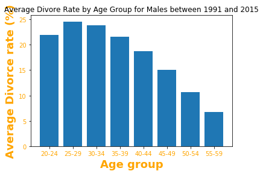

```python
# Choose the height of the bars
height = [uk_divorce_marriage_df['DRMale 20 to 24'].mean(), uk_divorce_marriage_df['DRMale 25 to 29'].mean(),uk_divorce_marriage_df['DRMale 30 to 34'].mean(),uk_divorce_marriage_df['DRMale 35 to 39'].mean(),uk_divorce_marriage_df['DRMale 40 to 44'].mean(),uk_divorce_marriage_df['DRMale 45 to 49'].mean(),uk_divorce_marriage_df['DRMale 50 to 54'].mean(),uk_divorce_marriage_df['DRMale 55 to 59'].mean()]

# Choose the names of the bars
bars = ('20-24', '25-29', '30-34', '35-39', '40-44','45-49','50-54','55-59')
y_pos = np.arange(len(bars))

# Create bars
plt.bar(y_pos, height)

# Create names on the x-axis
plt.xticks(y_pos, bars, color='orange')
plt.yticks(color='orange')

# Create x and y labels
plt.xlabel('Age group', fontweight='bold', color = 'orange', fontsize='18')
plt.ylabel('Average Divorce rate (%)', fontweight='bold', color = 'orange', fontsize='18')

#Create title for figure
plt.title("Average Divore Rate by Age Group for Males between 1991 and 2015")

# Show graphic
plt.show()
```

### Between 1991 and 2015, which age group between ages 20-59 had the highest/lowest average divorce rate for females?

The code below was used to determine which age group between ages 20-59 had the highest/lowest average divorce rate for females between 1991 and 2015. Between 1991 and 2015, the age group between ages 20-59 with the highest average divorce rate for females was females aged 25-29, and the age group between ages 20-59 with the lowest average divorce rate for females was females aged 55-59. As females aged, they were less likely to divorce. The bar plot visualizes the average divorce rate by age group for females between 1991 and 2015.

```python
print("Divorce rate for females ages 20-24:",uk_divorce_marriage_df['DRFemale 20 to 24'].mean())
print("Divorce rate for females ages 25-29:",uk_divorce_marriage_df['DRFemale 25 to 29'].mean())
print("Divorce rate for females ages 30-34:",uk_divorce_marriage_df['DRFemale 30 to 34'].mean())
print("Divorce rate for females ages 35-39:",uk_divorce_marriage_df['DRFemale 35 to 39'].mean())
print("Divorce rate for females ages 40-44:",uk_divorce_marriage_df['DRFemale 40 to 44'].mean())
print("Divorce rate for females ages 45-49:",uk_divorce_marriage_df['DRFemale 45 to 49'].mean())
print("Divorce rate for females ages 50-54:",uk_divorce_marriage_df['DRFemale 50 to 54'].mean())
print("Divorce rate for females ages 55-59:",uk_divorce_marriage_df['DRFemale 55 to 59'].mean())
```

```
Divorce rate for females ages 20-24: 23.632
Divorce rate for females ages 25-29: 25.212
Divorce rate for females ages 30-34: 22.768
Divorce rate for females ages 35-39: 19.916
Divorce rate for females ages 40-44: 16.932
Divorce rate for females ages 45-49: 12.812
Divorce rate for females ages 50-54: 8.28
Divorce rate for females ages 55-59: 4.752
```

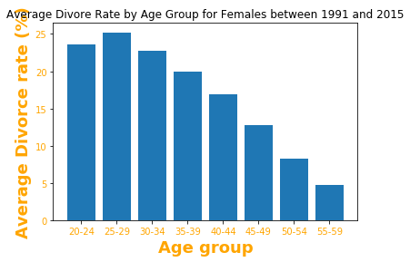

```python
# Choose the height of the bars
height = [uk_divorce_marriage_df['DRFemale 20 to 24'].mean(), uk_divorce_marriage_df['DRFemale 25 to 29'].mean(),uk_divorce_marriage_df['DRFemale 30 to 34'].mean(),uk_divorce_marriage_df['DRFemale 35 to 39'].mean(),uk_divorce_marriage_df['DRFemale 40 to 44'].mean(),uk_divorce_marriage_df['DRFemale 45 to 49'].mean(),uk_divorce_marriage_df['DRFemale 50 to 54'].mean(),uk_divorce_marriage_df['DRFemale 55 to 59'].mean()]

# Choose the names of the bars
bars = ('20-24', '25-29', '30-34', '35-39', '40-44','45-49','50-54','55-59')
y_pos = np.arange(len(bars))

# Create bars
plt.bar(y_pos, height)

# Create names on the x-axis
plt.xticks(y_pos, bars, color='orange')
plt.yticks(color='orange')

# Create x and y labels
plt.xlabel('Age group', fontweight='bold', color = 'orange', fontsize='18')
plt.ylabel('Average Divorce rate (%)', fontweight='bold', color = 'orange', fontsize='18')

#Create title for figure
plt.title("Average Divore Rate by Age Group for Females between 1991 and 2015")

# Show graphic
plt.show()
```

### How did the divorce rate for males aged 20-24, males aged 25-29, males aged 30-34, males aged 35-39, males aged 40-44, males aged 45-49, males aged 50-54, and males aged 55-59 change from 1991 to 2015?

The line graph below visualizes how the divorce rate for males aged 20-24, males aged 25-29, males aged 30-34, males aged 35-39, males aged 40-44, males aged 45-49, males aged 50-54, and males aged 55-59 changed from 1991 to 2015. From 1991 to 2015, the divorce rate for males aged 25-29, males aged 30-34, males aged 35-39, and males aged 40-44 decreased, while the divorce rate for males aged 45-49, males aged 50-54, and males aged 55-59 remained constant. Younger males divorced less frequently over the years.

```python
uk_male_dr_df_long=pd.melt(uk_divorce_marriage_df, id_vars=['Year'], value_vars=['DRMale 20 to 24', 'DRMale 25 to 29', 'DRMale 30 to 34','DRMale 35 to 39','DRMale 40 to 44','DRMale 45 to 49','DRMale 50 to 54','DRMale 55 to 59'])
fig = px.line(uk_male_dr_df_long, x='Year', y='value', color='variable')
fig.show()
```

[interactive chart not shown]

### How did the divorce rate for females aged 20-24, females aged 25-29, females aged 30-34, females aged 35-39, females aged 40-44, females aged 45-49, females aged 50-54, and females aged 55-59 change from 1991 to 2015?

The line graph below visualizes how the divorce rate for females aged 20-24, females aged 25-29, females aged 30-34, females aged 35-39, females aged 40-44, females aged 45-49, females aged 50-54, and females aged 55-59 changed from 1991 to 2015. From 1991 to 2015, the divorce rate for females aged 25-29, females aged 30-34, and females aged 35-39 decreased, while the divorce rate for females aged 40-44, females aged 45-49, females aged 50-54, and females aged 55-59 remained constant. Younger females divorced less frequently over the years.

```python
uk_female_dr_df_long=pd.melt(uk_divorce_marriage_df, id_vars=['Year'], value_vars=['DRFemale 20 to 24', 'DRFemale 25 to 29', 'DRFemale 30 to 34','DRFemale 35 to 39','DRFemale 40 to 44','DRFemale 45 to 49','DRFemale 50 to 54','DRFemale 55 to 59'])
fig = px.line(uk_female_dr_df_long, x='Year', y='value', color='variable')
fig.show()
```

[interactive chart not shown]

## Between 1991 and 2015, was the divorce rates for different age ranges significantly different? Has the divorce rate for different ranges changed since 1991? Which age groups were most likely to divorce?

- Here we look at the divorce rates of men and women in varying age ranges.
- This data looks at divorce rates of men and women in the age ranges: 20-24, 25-29, 30-34, 35-39, 40-44, 44-49, 50-54, and 54-59.
- We want to answer the question of whether the divorce rates for age ranges are signigicantly different and if the divorce rates for different age ranges have changed since 1991.

```python
age_df = uk_divorce_marriage_df.iloc[:, 0:20]
age_df = pd.DataFrame(age_df)
age_df.drop(age_df.columns[[1, 2, 3]], axis = 1, inplace = True)
age_df.head()
```

|  | Year | DRMale 20 to 24 | DRMale 25 to 29 | DRMale 30 to 34 | DRMale 35 to 39 | DRMale 40 to 44 | DRMale 45 to 49 | DRMale 50 to 54 | DRMale 55 to 59 | DRFemale 20 to 24 | DRFemale 25 to 29 | DRFemale 30 to 34 | DRFemale 35 to 39 | DRFemale 40 to 44 | DRFemale 45 to 49 | DRFemale 50 to 54 | DRFemale 55 to 59 |
| --- | --- | --- | --- | --- | --- | --- | --- | --- | --- | --- | --- | --- | --- | --- | --- | --- | --- |
| 1 | 2015 | 10.5 | 13.0 | 11.9 | 12.6 | 13.1 | 12.6 | 10.1 | 7.1 | 11.2 | 13.3 | 12.4 | 12.7 | 12.9 | 12.0 | 8.7 | 5.1 |
| 2 | 2014 | 13.2 | 13.5 | 14.0 | 13.9 | 14.6 | 13.7 | 11.0 | 7.4 | 12.1 | 14.8 | 14.5 | 13.8 | 14.9 | 12.8 | 9.4 | 5.5 |
| 3 | 2013 | 14.7 | 15.9 | 15.8 | 16.7 | 16.7 | 15.3 | 12.0 | 7.8 | 16.3 | 16.8 | 16.2 | 16.2 | 16.2 | 14.0 | 10.0 | 5.7 |
| 4 | 2012 | 17.5 | 17.4 | 17.3 | 17.9 | 17.8 | 15.8 | 11.9 | 7.7 | 17.0 | 18.7 | 17.5 | 17.0 | 16.8 | 14.3 | 9.7 | 5.7 |
| 5 | 2011 | 19.5 | 17.1 | 18.8 | 17.9 | 18.0 | 15.4 | 11.5 | 7.6 | 16.4 | 18.5 | 18.5 | 17.5 | 16.9 | 13.9 | 9.5 | 5.5 |

```python
age_df_mod = pd.melt(age_df, id_vars=['Year'], value_vars=age_df.keys()[1:], var_name='Age')
fig = px.line(age_df_mod, x='Year', y='value', color='Age')
fig.show()
```

[interactive chart not shown]

### Between 1991 and 2015, which age group had the highest divorce rate per year?

```python
age_df.set_index('Year', inplace = True, drop = True)
numeric_age_df = age_df.idxmax(axis=1)
numeric_age_df.head()
```

```
Year
2015    DRFemale 25 to 29
2014    DRFemale 40 to 44
2013    DRFemale 25 to 29
2012    DRFemale 25 to 29
2011      DRMale 20 to 24
dtype: object
```

```python
age_df2 = uk_divorce_marriage_df.iloc[:, [0,4,5,6,7,8,9,12,13,14,15,16,17]]
age_df2 = pd.DataFrame(age_df2)
#age_df2.drop(age_df.columns[[1, 2, 3]], axis = 1, inplace = True)
age_df2.head()
```

|  | Year | DRMale 20 to 24 | DRMale 25 to 29 | DRMale 30 to 34 | DRMale 35 to 39 | DRMale 40 to 44 | DRMale 45 to 49 | DRFemale 20 to 24 | DRFemale 25 to 29 | DRFemale 30 to 34 | DRFemale 35 to 39 | DRFemale 40 to 44 | DRFemale 45 to 49 |
| --- | --- | --- | --- | --- | --- | --- | --- | --- | --- | --- | --- | --- | --- |
| 1 | 2015 | 10.5 | 13.0 | 11.9 | 12.6 | 13.1 | 12.6 | 11.2 | 13.3 | 12.4 | 12.7 | 12.9 | 12.0 |
| 2 | 2014 | 13.2 | 13.5 | 14.0 | 13.9 | 14.6 | 13.7 | 12.1 | 14.8 | 14.5 | 13.8 | 14.9 | 12.8 |
| 3 | 2013 | 14.7 | 15.9 | 15.8 | 16.7 | 16.7 | 15.3 | 16.3 | 16.8 | 16.2 | 16.2 | 16.2 | 14.0 |
| 4 | 2012 | 17.5 | 17.4 | 17.3 | 17.9 | 17.8 | 15.8 | 17.0 | 18.7 | 17.5 | 17.0 | 16.8 | 14.3 |
| 5 | 2011 | 19.5 | 17.1 | 18.8 | 17.9 | 18.0 | 15.4 | 16.4 | 18.5 | 18.5 | 17.5 | 16.9 | 13.9 |

```python
age_df_mod2 = pd.melt(age_df2, id_vars=['Year'], value_vars=age_df2.keys()[1:12], var_name='Age')
fig = px.line(age_df_mod2, x='Year', y='value', color='Age')
fig.show()
```

[interactive chart not shown]

#### Findings

- Between 1991 and 2015, the age group with the highest divorce rate every year was either age group 20-24 or 25-29 (with two outliers being in 2014 and 2010), reaffirming that divorce rates are much higher amongst younger people in the UK than older people.

### Between 1991 and 2015, were husbands more likely to divorce because of adultery, or because of unreasonable behavior?

The code below was used to determine whether husbands were more likely to divorce because of adultery or unreasonable behavior between 1991 and 2015. Between 1991 and 2015, the total number of divorces submitted by husbands because of adultery was less than the total number of divorces submitted by husbands because of unreasonable behavior. Therefore, husbands were more likely to divorce because of unreasonable behavior from their wife than because of adultery from their wife.

```python
print("Total number of divorces submitted by husbands because of adultery:",uk_divorce_marriage_df['Husband Submitted - Reason Adultery'].sum())
print("Total number of divorces submitted by husbands because of unreasonable behavior:",uk_divorce_marriage_df['Husband Submitted - Reason Unreasonable Behaviour'].sum())
```

```
Total number of divorces submitted by husbands because of adultery: 278558.0
Total number of divorces submitted by husbands because of unreasonable behavior: 321614.0
```

### Between 1991 and 2015, were wives more likely to divorce because of adultery, or because of unreasonable behavior?

The code below was used to determine whether wives were more likely to divorce because of adultery or unreasonable behavior between 1991 and 2015. Between 1991 and 2015, the total number of divorces submitted by wives because of adultery was less than the total number of divorces submitted by wives because of unreasonable behavior. Therefore, wives were more likely to divorce because of unreasonable behavior from their husband than adultery from their husband.

```python
print("Total number of divorces submitted by wives because of adultery:",uk_divorce_marriage_df['Wife Submitted - Reason Adultery'].sum())
print("Total number of divorces submitted by wives because of unreasonable behavior:",uk_divorce_marriage_df['Wife Submitted - Reason Unreasonable Behaviour'].sum())
```

[output not shown]

### Between 1991 and 1995, how did the causes of divorce (filing for divorce because of adultery and filing for divorce because of unreasonable behavior) change over time?

- Here we chose to look at people filing for divorce because of adultery and filing for divorce because of unreasonable behavior, and in which gender they occured more often.
- First we add columns that show the percentage of adultery and unreasonable behavior divorces, and then the percentages for each gender.

```python
uk_divorce_marriage_df2=uk_divorce_marriage_df
uk_divorce_marriage_df2['Adultery %'] = (uk_divorce_marriage_df2['Wife Submitted - Reason Adultery'] + uk_divorce_marriage_df2['Husband Submitted - Reason Adultery'])/uk_divorce_marriage_df2['Total Number of Marriages']
uk_divorce_marriage_df2['Unreasonable %'] = (uk_divorce_marriage_df2['Wife Submitted - Reason Unreasonable Behaviour'] + uk_divorce_marriage_df2['Husband Submitted - Reason Unreasonable Behaviour'])/uk_divorce_marriage_df2['Total Number of Marriages']

uk_divorce_marriage_df2['Husband Sub Unreasonable %'] = (uk_divorce_marriage_df2['Husband Submitted - Reason Unreasonable Behaviour'])/uk_divorce_marriage_df2['Total Number of Marriages']
uk_divorce_marriage_df2['Wife Sub Unreasonable %'] = (uk_divorce_marriage_df2['Wife Submitted - Reason Unreasonable Behaviour'])/uk_divorce_marriage_df2['Total Number of Marriages']

uk_divorce_marriage_df2['Husband Sub For Adltry %'] = (uk_divorce_marriage_df2['Husband Submitted - Reason Adultery'])/uk_divorce_marriage_df2['Total Number of Marriages']
uk_divorce_marriage_df2['Wife Sub For Adltry %'] = (uk_divorce_marriage_df2['Wife Submitted - Reason Adultery'])/uk_divorce_marriage_df2['Total Number of Marriages']
uk_divorce_marriage_df2.head()
```

|  | Year | Total Number of Divorces | Husband Submitted Divorce | Wife Submitted Divorce | DRMale 20 to 24 | DRMale 25 to 29 | DRMale 30 to 34 | DRMale 35 to 39 | DRMale 40 to 44 | DRMale 45 to 49 | ... | Number Men First Time marrying per 1,000 single population aged 16 and over | Number Women First Time marrying per 1,000 single population aged 16 and over | Number Men Re-marrying per 1,000 single population aged 16 and over | Number Women Re-marrying per 1,000 single population aged 16 and over | Adultery % | Unreasonable % | Husband Sub Unreasonable % | Wife Sub Unreasonable % | Husband Sub For Adltry % | Wife Sub For Adltry % |
| --- | --- | --- | --- | --- | --- | --- | --- | --- | --- | --- | --- | --- | --- | --- | --- | --- | --- | --- | --- | --- | --- |
| 1 | 2015 | 101055 | 38490 | 62565 | 10.5 | 13.0 | 11.9 | 12.6 | 13.1 | 12.6 | ... | 20.7 | 24.3 | 25.4 | 12.5 | 0.050824 | 0.195862 | 0.059321 | 0.136541 | 0.018722 | 0.032102 |
| 2 | 2014 | 111169 | 41364 | 69803 | 13.2 | 13.5 | 14.0 | 13.9 | 14.6 | 13.7 | ... | 22.1 | 25.9 | 26.2 | 12.8 | 0.056797 | 0.212385 | 0.063184 | 0.149200 | 0.020689 | 0.036108 |
| 3 | 2013 | 114720 | 40635 | 74076 | 14.7 | 15.9 | 15.8 | 16.7 | 16.7 | 15.3 | ... | 21.7 | 25.6 | 25.3 | 12.2 | 0.062984 | 0.229230 | 0.063657 | 0.165573 | 0.021851 | 0.041133 |
| 4 | 2012 | 118140 | 41601 | 76490 | 17.5 | 17.4 | 17.3 | 17.9 | 17.8 | 15.8 | ... | 23.9 | 28.4 | 27.2 | 13.4 | 0.060670 | 0.214148 | 0.057692 | 0.156456 | 0.021526 | 0.039144 |
| 5 | 2011 | 117558 | 40414 | 77083 | 19.5 | 17.1 | 18.8 | 17.9 | 18.0 | 15.4 | ... | 22.6 | 26.6 | 26.2 | 12.9 | 0.069449 | 0.226514 | 0.058591 | 0.167922 | 0.024778 | 0.044671 |

5 rows × 45 columns

```python
uk_divorce_marriage_df_causes=pd.melt(uk_divorce_marriage_df2, id_vars=['Year'], value_vars=['Adultery %', 'Unreasonable %'])
fig = px.line(uk_divorce_marriage_df_causes, x='Year', y='value', color='variable')
fig.show()
```

[interactive chart not shown]

```python
uk_divorce_marriage_df_causes=pd.melt(uk_divorce_marriage_df2, id_vars=['Year'], value_vars=['Husband Sub For Adltry %', 'Wife Sub For Adltry %'])
fig = px.line(uk_divorce_marriage_df_causes, x='Year', y='value', color='variable')
fig.show()
```

[interactive chart not shown]

```python
uk_divorce_marriage_df_causes=pd.melt(uk_divorce_marriage_df2, id_vars=['Year'], value_vars=['Husband Sub Unreasonable %', 'Wife Sub Unreasonable %'])
fig = px.line(uk_divorce_marriage_df_causes, x='Year', y='value', color='variable')
fig.show()
```

[interactive chart not shown]

Between 1991 and 2015, the prevalence of divorce being filed because of adultery or because of unreasonable behavior went down significantly over the years, for both men and women. During the time period, it was more likely for a person to file for divorce because of unreasonable behavior than adultery, for both men and women.

### Between 1991 and 2015, how many marriages consisted of people who both married for the first time, a person who previously divorced, people who both previously divorced, the husband previously divorcing, and the wife previously divorcing?

The code below was used to determine how many marriages consisted of people who both married for the first time, a person who previously divorced, people who both previously divorced, the husband previously divorcing, and the wife previously divorcing between 1991 and 2015. Between 1991 and 2015, the number of marriages consisting of people who both married for the first time was 2,411,751, the number of marriages consisting of a person who previously divorced was 659,441, the number of marriages consisting of people who both previously divorced was 326,570, the number of marriages consisting of the husband previously divorcing was 665,693, and the number of marriages consisting of the wife previously divorcing was 647,657. A marriage was most likely to consist of people marrying for the first time, and least likely to consist of people who both previously divorced. The bar plot visualizes the number of marriages by marriage composition between 1991 and 2015.

```python
print("Marriages consisting of people who both married for the first time:",uk_divorce_marriage_df['First marriage of both parties'].sum())
print("Marriages consisting of a person who previously divorced:",uk_divorce_marriage_df['One party previously divorced'].sum())
print("Marriages consisting of people who both previously divorced:",uk_divorce_marriage_df['Both parties previously divorced'].sum())
print("Marriages consisting of the husband previously divorcing:",uk_divorce_marriage_df['Husband - Previously Divorced'].sum())
print("Marriages consisting of the wife previously divorcing:",uk_divorce_marriage_df['Wife - Previously Divorced'].sum())
```

```
Marriages consisting of people who both married for the first time: 2411751
Marriages consisting of a person who previously divorced: 659441
Marriages consisting of people who both previously divorced: 326570
Marriages consisting of the husband previously divorcing: 665693
Marriages consisting of the wife previously divorcing: 647657
```

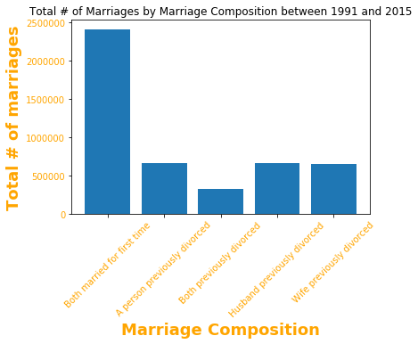

```python
# Choose the height of the bars
height = [uk_divorce_marriage_df['First marriage of both parties'].sum(),uk_divorce_marriage_df['One party previously divorced'].sum(),uk_divorce_marriage_df['Both parties previously divorced'].sum(),uk_divorce_marriage_df['Husband - Previously Divorced'].sum(),uk_divorce_marriage_df['Wife - Previously Divorced'].sum()]

# Choose the names of the bars
bars = ('Both married for first time', 'A person previously divorced', 'Both previously divorced', 'Husband previously divorced', 'Wife previously divorced')
y_pos = np.arange(len(bars))

# Create bars
plt.bar(y_pos, height)

# Create names on the x-axis
plt.xticks(y_pos, bars, color='orange',rotation=45)
plt.yticks(color='orange')

# Create x and y labels
plt.xlabel('Marriage Composition', fontweight='bold', color = 'orange', fontsize='18')
plt.ylabel('Total # of marriages', fontweight='bold', color = 'orange', fontsize='18')

#Create title for figure
plt.title("Total # of Marriages by Marriage Composition between 1991 and 2015")

# Show graphic
plt.show()
```

### How did the number of marriages consisting of people who both married for the first time, a person who previously divorced, people who both previously divorced, the husband previously divorcing, and the wife previously divorcing change from 1991 to 2015?

The line graph below visualizes how the number of marriages consisting of people who both married for the first time, a person who previously divorced, people who both previously divorced, the husband previously divorcing, and the wife previously divorcing has changed from 1991 and to 2015. From 1991 to 2015, the number of marriages consisting of people who both married for the first time decreased, while the number of marriages consisting of a person who previously divorced, people who both previously divorced, the husband previously divorcing, and the wife previously divorcing remained relatively constant. Marriages consisting of people marrying for the first time became less common over the years.

```python
uk_marriage_composition_df_long=pd.melt(uk_divorce_marriage_df, id_vars=['Year'], value_vars=['First marriage of both parties', 'One party previously divorced','Both parties previously divorced','Husband - Previously Divorced','Wife - Previously Divorced'])
fig = px.line(uk_marriage_composition_df_long, x='Year', y='value', color='variable')
fig.show()
```

[interactive chart not shown]

### Which 5 years had the highest and lowest median age for males getting married between 1991 and 2015?

The tables below show the 5 years with the highest and lowest median age for males getting married between 1991 and 2015. Between 1991 and 2015, the 5 years with the highest median age for males getting married were 2015, 2014, 2013, 2012, and 2011. The 5 years with the lowest median age for males getting married were 1991, 1992, 1993, 1994, and 1995. Over time, males got married at an older age.

```python
top5_years_median_age_male=uk_divorce_marriage_df[['Year','Median Age of Single Males Marriage']].sort_values('Median Age of Single Males Marriage', ascending=False).head(5)
top5_years_median_age_male
```

|  | Year | Median Age of Single Males Marriage |
| --- | --- | --- |
| 1 | 2015 | 31.5 |
| 2 | 2014 | 31.2 |
| 3 | 2013 | 31.1 |
| 4 | 2012 | 31.0 |
| 5 | 2011 | 30.9 |

```python
bottom5_years_median_age_male=uk_divorce_marriage_df[['Year','Median Age of Single Males Marriage']].sort_values('Median Age of Single Males Marriage', ascending=True).head(5)
bottom5_years_median_age_male
```

|  | Year | Median Age of Single Males Marriage |
| --- | --- | --- |
| 25 | 1991 | 26.5 |
| 24 | 1992 | 26.8 |
| 23 | 1993 | 27.2 |
| 22 | 1994 | 27.5 |
| 21 | 1995 | 27.9 |

### Which 5 years had the highest and lowest median age for females getting married between 1991 and 2015?

The tables below show the 5 years with the highest and lowest median age for females getting married between 1991 and 2015. Between 1991 and 2015, the 5 years with the highest median age for females getting married were 2015, 2014, 2013, 2012, and 2011. The 5 years with the lowest median age for females getting married were 1991, 1992, 1993, 1994, and 1995. Over time, females got married at an older age.

```python
top5_years_median_age_female=uk_divorce_marriage_df[['Year','Median Age of Single Females Marriage']].sort_values('Median Age of Single Females Marriage', ascending=False).head(5)
top5_years_median_age_female
```

|  | Year | Median Age of Single Females Marriage |
| --- | --- | --- |
| 1 | 2015 | 29.7 |
| 2 | 2014 | 29.5 |
| 3 | 2013 | 29.3 |
| 4 | 2012 | 29.1 |
| 5 | 2011 | 29.1 |

```python
bottom5_years_median_age_female=uk_divorce_marriage_df[['Year','Median Age of Single Females Marriage']].sort_values('Median Age of Single Females Marriage', ascending=True).head(5)
bottom5_years_median_age_female
```

|  | Year | Median Age of Single Females Marriage |
| --- | --- | --- |
| 25 | 1991 | 24.6 |
| 24 | 1992 | 25.0 |
| 23 | 1993 | 25.3 |
| 22 | 1994 | 25.7 |
| 21 | 1995 | 26.0 |

### From 1991 to 2015, how many years was the median age for men getting married greater than the median age for women getting married?

The code below was used to determine the number of years the median age for men getting married was greater than the median age for women getting married. From 1991 to 2015, the number of years the median age for men getting married was greater than the median age for women getting married was 25. Every year, the median age for males getting married was greater than the median age for females getting married, showing that males tended to marry younger women.

```python
years=0
for i in range(1,uk_divorce_marriage_df.shape[0]+1):
    men_median_age=uk_divorce_marriage_df.loc[i,'Median Age of Single Males Marriage']
    women_median_age=uk_divorce_marriage_df.loc[i,'Median Age of Single Females Marriage']
    if(men_median_age>women_median_age):
        years=years+1
print("The number of years where the median age of men getting married was greater than the median age of women getting married:",years)
```

```
The number of years where the median age of men getting married was greater than the median age of women getting married: 25
```

### How did the median age for males and females getting married change from 1991 to 2015?

The line graph below visualizes how the median age of males and females getting married changed from 1991 and to 2015. From 1991 to 2015, the the median age for males and females getting married increased. Males and females got married at an older age over the years.

```python
uk_median_age_marriage_df_long=pd.melt(uk_divorce_marriage_df, id_vars=['Year'], value_vars=['Median Age of Single Males Marriage', 'Median Age of Single Females Marriage'])
fig = px.line(uk_median_age_marriage_df_long, x='Year', y='value', color='variable')
fig.show()
```

[interactive chart not shown]

### From 1991 to 2015, how many years was the number of men marrying per 1,000 unmarried men greater than the number of women marrying per 1,000 unmarried women?

The code below was used to determine the number of years the number of men marrying per 1,000 unmarried men was greater than the number of women marrying per 1,000 unmarried women from 1991 to 2015. From 1991 to 2015, the number of years where the number of men marrying per 1,000 unmarried men was greater than the number of women marrying per 1,000 unmarried women was 25. Every year, the number of men marrying per 1,000 unmarried men was greater than the number of women marrying per 1,000 unmarried women, showing that more males tended to marry than women.

```python
years=0
for i in range(1,uk_divorce_marriage_df.shape[0]+1):
    num_men_marrying_each_1000=uk_divorce_marriage_df.loc[i,'Men marrying per 1,000 unmarried1 men aged 16 and over']
    num_women_marrying_each_1000=uk_divorce_marriage_df.loc[i,'Women marrying per 1,000 unmarried1 women aged 16 and over']
    if(num_men_marrying_each_1000>num_women_marrying_each_1000):
        years=years+1
print("The number of years where the the number of men marrying per 1,000 unmarried men was greater than the number of women marrying per 1,000 unmarried women:",years)
```

```
The number of years where the the number of men marrying per 1,000 unmarried men was greater than the number of women marrying per 1,000 unmarried women: 25
```

### How did the number of men and marrying per 1,000 unmarried men and number of women marrying per 1,000 unmarried women change from 1991 to 2015?

The line graph below visualizes how the number of men marrying per 1,000 unmarried men and number of women marrying per 1,000 unmarried women changed from 1991 to 2015. From 1991 to 2015, the number of men marrying per 1,000 unmarried men and number of women marrying per 1,000 unmarried women decreased. Males and females married less frequently over the years.

```python
uk_marriage_every_1000_df_long=pd.melt(uk_divorce_marriage_df, id_vars=['Year'], value_vars=['Men marrying per 1,000 unmarried1 men aged 16 and over', 'Women marrying per 1,000 unmarried1 women aged 16 and over'])
fig = px.line(uk_marriage_every_1000_df_long, x='Year', y='value', color='variable')
fig.show()
```

[interactive chart not shown]

### From 1991 to 2015, how many years was the number of men marrying for the first time per 1,000 people greater than number of women marrying for the first time per 1,000 people?

The code below was used to determine the number of years where the number of men marrying for the first time per 1,000 people was greater than number of women marrying for the first time per 1,000 people from 1991 to 2015. From 1991 to 2015, the number of years where the number of men marrying for the first time per 1,000 people was greater than number of women marrying for the first time per 1,000 people was 0. Every year, the number of men marrying for the first time per 1,000 people was less than the number of women marrying for the first time per 1,000 people, showing that less men tended to marry for the first time than women.

```python
years=0
for i in range(1,uk_divorce_marriage_df.shape[0]+1):
    num_men_marrying_first_time_each_1000=uk_divorce_marriage_df.loc[i,'Number Men First Time marrying per 1,000 single population aged 16 and over']
    num_women_marrying_first_time_each_1000=uk_divorce_marriage_df.loc[i,'Number Women First Time marrying per 1,000 single population aged 16 and over']
    if(num_men_marrying_first_time_each_1000>num_women_marrying_first_time_each_1000):
        years=years+1
print("The number of years where the number of men marrying for the first time per 1,000 people was greater than number of women marrying for the first time per 1,000 people:",years)
```

```
The number of years where the number of men marrying for the first time per 1,000 people was greater than number of women marrying for the first time per 1,000 people: 0
```

### How did the number of men marrying for the first time per 1,000 people and number of women marrying for the first time per 1,000 people change from 1991 to 2015?

The line graph below visualizes how the number of men marrying for the first time per 1,000 people and number of women marrying for the first time per 1,000 people changed from 1991 to 2015. From 1991 to 2015, the number of men marrying for the first time per 1,000 people and number of women marrying for the first time per 1,000 people decreased. Men and women got married for the first time less frequently over the years. Less marriages consisted of people getting married for the first time over the years.

```python
uk_marriage_first_time_every_1000_df_long=pd.melt(uk_divorce_marriage_df, id_vars=['Year'], value_vars=['Number Men First Time marrying per 1,000 single population aged 16 and over', 'Number Women First Time marrying per 1,000 single population aged 16 and over'])
fig = px.line(uk_marriage_first_time_every_1000_df_long, x='Year', y='value', color='variable')
fig.show()
```

[interactive chart not shown]

### From 1991 to 2015, how many years was the number of men remarrying per 1,000 people greater than the number of women remarrying per 1,000 people?

The code below was used to determine the number of years where the number of men remarrying per 1,000 people was greater than the number of women remarrying per 1,000 people from 1991 to 2015. From 1991 to 2015, the number of years where the number of men remarrying per 1,000 people was greater than the number of women remarrying per 1,000 people was 25. Every year, the number of men remarrying per 1,000 people was greater than the number of women remarrying per 1,000 people, showing that more men tended to remarry than women.

```python
years=0
for i in range(1,uk_divorce_marriage_df.shape[0]+1):
    num_men_remarrying_each_1000=uk_divorce_marriage_df.loc[i,'Number Men Re-marrying per 1,000 single population aged 16 and over']
    num_women_remarrying_each_1000=uk_divorce_marriage_df.loc[i,'Number Women Re-marrying per 1,000 single population aged 16 and over']
    if(num_men_remarrying_each_1000>num_women_remarrying_each_1000):
        years=years+1
print("The number of years where the number of men remarrying per 1,000 people was greater than the number of women remarrying per 1,000 people:",years)
```

```
The number of years where the number of men remarrying per 1,000 people was greater than the number of women remarrying per 1,000 people: 25
```

### How did the number of men remarrying per 1,000 people and number of women remarrying per 1,000 people change from 1991 to 2015?

The line graph below visualizes how the number of men remarrying per 1,000 people and number of women remarrying per 1,000 people changed from 1991 to 2015. From 1991 to 2015, the number of men remarrying per 1,000 people and number of women remarrying per 1,000 people decreased. Men and womem got remarried less frequently over the years.

```python
uk_remarrying_every_1000_df_long=pd.melt(uk_divorce_marriage_df, id_vars=['Year'], value_vars=['Number Men Re-marrying per 1,000 single population aged 16 and over', 'Number Women Re-marrying per 1,000 single population aged 16 and over'])
fig = px.line(uk_remarrying_every_1000_df_long, x='Year', y='value', color='variable')
fig.show()
```

[interactive chart not shown]

### From 1991 to 2015, how many years was the number of men marrying for the first time per 1,000 people greater than the number of men remarrying per 1,000 people?

The code below was used to determine the number of years where the number of men marrying for the first time per 1,000 people was greater than the number of men remarrying per 1,000 people from 1991 to 2015. From 1991 to 2015, the number of years where the number of men marrying for the first time per 1,000 people was greater than the number of men remarrying per 1,000 people was 0. Every year, the number of men marrying for the first time per 1,000 people was less than the number of men remarrying per 1,000 people, showing that men were more likely to be getting remarried than getting married for the first time.

```python
years=0
for i in range(1,uk_divorce_marriage_df.shape[0]+1):
    num_men_marrying_first_time_each_1000=uk_divorce_marriage_df.loc[i,'Number Men First Time marrying per 1,000 single population aged 16 and over']
    num_men_remarrying_each_1000=uk_divorce_marriage_df.loc[i,'Number Men Re-marrying per 1,000 single population aged 16 and over']
    if(num_men_marrying_first_time_each_1000>num_men_remarrying_each_1000):
        years=years+1
print("The number of years where the number of men marrying for the first time per 1,000 people was greater than the number of men remarrying per 1,000 people:",years)
```

```
The number of years where the number of men marrying for the first time per 1,000 people was greater than the number of men remarrying per 1,000 people: 0
```

### From 1991 to 2015, how many years was the number of women marrying for the first time per 1,000 people greater than the number of women remarrying per 1,000 people?

The code below was used to determine the number of years where the number of women marrying for the first time per 1,000 people was greater than the number of women remarrying per 1,000 people from 1991 to 2015. From 1991 to 2015, the number of years where the number of women marrying for the first time per 1,000 people was greater than the number of women remarrying per 1,000 people was 25. Every year, the number of women marrying for the first time per 1,000 people was greater than the number of women remarrying per 1,000 people, showing that women were more likely to be getting married for the first time than getting remarried.

```python
years=0
for i in range(1,uk_divorce_marriage_df.shape[0]+1):
    num_women_marrying_first_time_each_1000=uk_divorce_marriage_df.loc[i,'Number Women First Time marrying per 1,000 single population aged 16 and over']
    num_women_remarrying_each_1000=uk_divorce_marriage_df.loc[i,'Number Women Re-marrying per 1,000 single population aged 16 and over']
    if(num_women_marrying_first_time_each_1000>num_women_remarrying_each_1000):
        years=years+1
print("The number of years where the number of women marrying for the first time per 1,000 people was greater than the number of women remarrying per 1,000 people:",years)
```

```
The number of years where the number of women marrying for the first time per 1,000 people was greater than the number of women remarrying per 1,000 people: 25
```

# Conclusion

From our analysis, the following findings/results were found in relation to UK divorce and marriage from 1991 to 2015: